```python
import pandas as pd
import numpy as np
import seaborn as sns
```

# 문제 1 - 20점

### 문제 [1-1] - 3점

### 2023년 1월 29일, 자신의 이름, MBTI, 핸드폰 번호 뒷자리를 리스트로 저장하고 그것을 Series의 형태로 변환하여 출력하세요.

```python
list_data = ['2023-01-29','홍길동','ESFP','0123']
sr = pd.Series(list_data)
print(sr)
print(type(sr))
```

```
0    2023-01-29
1           홍길동
2          ESFP
3          0123
dtype: object
<class 'pandas.core.series.Series'>
```

### 문제 [1-2] - 3점

### 딕셔너리를 사용하여 다음의 DataFrame 모양을 만들어 출력하세요.(DataFrame은 df로 저장해주세요)

```python
exam_data = {'국어' : [95,85,80], '수학' : [100,85,90], '영어' : [90,90,80], '탐구' : [80,100,90]}
df = pd.DataFrame(exam_data, index = ['사람1', '사람2', '사람3'])
df
```

|  | 국어 | 수학 | 영어 | 탐구 |
| --- | --- | --- | --- | --- |
| 사람1 | 95 | 100 | 90 | 80 |
| 사람2 | 85 | 85 | 90 | 100 |
| 사람3 | 80 | 90 | 80 | 90 |

### 문제 [1-3] - 3점

### 위에서 만들어진 df에서 '탐구'열(column)을 삭제하고 출력하세요.

```python
df.drop('탐구', axis = 1, inplace = True)
df
```

|  | 국어 | 수학 | 영어 |
| --- | --- | --- | --- |
| 사람1 | 95 | 100 | 90 |
| 사람2 | 85 | 85 | 90 |
| 사람3 | 80 | 90 | 80 |

### 문제 [1-4] - 4점

### df에 국어, 수학, 영어 3과목의 평균 점수를 나타내는 '평균' 열(column)을 추가하여 출력하세요.(소수점 세번째 자리에서 반올림하여 소수점 둘째자리까지만 나타내세요)

```python
df['평균'] = round((df['국어'] + df['수학'] + df['영어']) / 3 , 2)
df
```

|  | 국어 | 수학 | 영어 | 평균 |
| --- | --- | --- | --- | --- |
| 사람1 | 95 | 100 | 90 | 95.00 |
| 사람2 | 85 | 85 | 90 | 86.67 |
| 사람3 | 80 | 90 | 80 | 83.33 |

### 문제 [1-5] - 7점

### '평균'열에 나온 점수를 기준으로 등급으로 변환한 '등급'열을 추가하여 출력하세요(95점 이상 A+, 90점 이상 A, 85점 이상 B+, 80점 이상 B 입니다.)

```python
grades = []
for i in df['평균']:
  if i >= 95:
    grades.append('A+')
  elif i >= 85:
    grades.append('B+')
  else:
    grades.append('B')

df['등급'] = grades
df
```

|  | 국어 | 수학 | 영어 | 평균 | 등급 |
| --- | --- | --- | --- | --- | --- |
| 사람1 | 95 | 100 | 90 | 95.00 | A+ |
| 사람2 | 85 | 85 | 90 | 86.67 | B+ |
| 사람3 | 80 | 90 | 80 | 83.33 | B |

# 문제 2 - 25점

### 문제 [2-1] - 3점

### spotify.csv 파일을 불러오고 data 변수에 저장하여 맨 위에 3개 행을 출력하세요.

```python
data = pd.read_csv('spotify.csv')
data.head(3)
```

|  | Country | Rank | Track_id | Streams | Track Name | Artist | URL | acousticness | danceability | energy | ... | valence | tempo | time_signature | duration_ms | key | mode | Artist_id | Artist_popularity | Artist_follower | Artist_img |
| --- | --- | --- | --- | --- | --- | --- | --- | --- | --- | --- | --- | --- | --- | --- | --- | --- | --- | --- | --- | --- | --- |
| 0 | global | 1.0 | 25sgk305KZfyuqVBQIahim | 1166185736 | Sweet but Psycho | Ava Max | https://open.spotify.com/track/25sgk305KZfyuqV... | 0.0691 | 0.719 | 0.704 | ... | 0.628 | 133.002 | 4 | 187436 | 1 | 1 | 4npEfmQ6YuiwW1GpUmaq3F | 87 | 1025358 | https://i.scdn.co/image/4b914c6470c8458674538a... |
| 1 | global | 2.0 | 2Fxmhks0bxGSBdJ92vM42m | 1052358787 | bad guy | Billie Eilish | https://open.spotify.com/track/2Fxmhks0bxGSBdJ... | 0.3280 | 0.701 | 0.425 | ... | 0.562 | 135.128 | 4 | 194088 | 7 | 1 | 6qqNVTkY8uBg9cP3Jd7DAH | 98 | 18867904 | https://i.scdn.co/image/2622edec99d68d1d141886... |
| 2 | global | 3.0 | 6ocbgoVGwYJhOv1GgI9NsF | 789094044 | 7 rings | Ariana Grande | https://open.spotify.com/track/6ocbgoVGwYJhOv1... | 0.5920 | 0.778 | 0.317 | ... | 0.327 | 140.048 | 4 | 178627 | 1 | 0 | 66CXWjxzNUsdJxJ2JdwvnR | 97 | 40958727 | https://i.scdn.co/image/b1dfbe843b0b9f54ab2e58... |

3 rows × 24 columns

### 문제 [2-2] - 3점

### data의 열(column) 중에서 'Artist'열에서 고유값의 종류와 갯수를 확인할 수 있는 함수를 쓰고 다음과 같이 출력하세요.

```python
data['Artist'].value_counts()
```

```
Post Malone      45
Juice WRLD       31
Ariana Grande    28
Billie Eilish    27
Taylor Swift     27
                 ..
Leona Lewis       1
Kylie Minogue     1
Omar Montes       1
Paloma Mami       1
Bee Gees          1
Name: Artist, Length: 488, dtype: int64
```

### 문제 [2-3] - 5점

### 'Artist'열에서 아티스트가 BTS인 행들을 찾아 출력하세요.

```python
data[data['Artist'] == 'BTS']
```

|  | Country | Rank | Track_id | Streams | Track Name | Artist | URL | acousticness | danceability | energy | ... | valence | tempo | time_signature | duration_ms | key | mode | Artist_id | Artist_popularity | Artist_follower | Artist_img |
| --- | --- | --- | --- | --- | --- | --- | --- | --- | --- | --- | --- | --- | --- | --- | --- | --- | --- | --- | --- | --- | --- |
| 86 | global | 87.0 | 5KawlOMHjWeUjQtnuRs22c | 261504425 | Boy With Luv (feat. Halsey) | BTS | https://open.spotify.com/track/5KawlOMHjWeUjQt... | 0.0923 | 0.645 | 0.862 | ... | 0.798 | 119.991 | 4 | 229773 | 11 | 0 | 3Nrfpe0tUJi4K4DXYWgMUX | 93 | 15652748 | https://i.scdn.co/image/0c9057cb30520f9f883a22... |
| 464 | global | 465.0 | 314ZkcV7oLWG8yWE7LABvH | 42873724 | Make It Right (feat. Lauv) | BTS | https://open.spotify.com/track/314ZkcV7oLWG8yW... | 0.0304 | 0.584 | 0.685 | ... | 0.345 | 97.551 | 4 | 226321 | 7 | 1 | 3Nrfpe0tUJi4K4DXYWgMUX | 93 | 15652748 | https://i.scdn.co/image/0c9057cb30520f9f883a22... |
| 676 | global | 677.0 | 5hnbE5BF2e8BCk9OMR1UVC | 18801822 | Mikrokosmos | BTS | https://open.spotify.com/track/5hnbE5BF2e8BCk9... | 0.1250 | 0.580 | 0.858 | ... | 0.475 | 174.039 | 3 | 224225 | 8 | 1 | 3Nrfpe0tUJi4K4DXYWgMUX | 93 | 15652748 | https://i.scdn.co/image/0c9057cb30520f9f883a22... |
| 678 | global | 679.0 | 4c1WgUnHXq2LEncGHKgj1I | 18648089 | Dream Glow (BTS World Original Soundtrack) - P... | BTS | https://open.spotify.com/track/4c1WgUnHXq2LEnc... | 0.0967 | 0.735 | 0.740 | ... | 0.541 | 141.948 | 4 | 187458 | 0 | 0 | 3Nrfpe0tUJi4K4DXYWgMUX | 93 | 15652748 | https://i.scdn.co/image/0c9057cb30520f9f883a22... |
| 681 | global | 682.0 | 6KUE0HSSudAp9AOycaF6SH | 18423901 | Make It Right | BTS | https://open.spotify.com/track/6KUE0HSSudAp9AO... | 0.0104 | 0.638 | 0.703 | ... | 0.261 | 105.766 | 4 | 226321 | 7 | 1 | 3Nrfpe0tUJi4K4DXYWgMUX | 93 | 15652748 | https://i.scdn.co/image/0c9057cb30520f9f883a22... |
| 710 | global | 711.0 | 7lthOBXNue2IvedLRfkod8 | 16442038 | HOME | BTS | https://open.spotify.com/track/7lthOBXNue2Ived... | 0.0142 | 0.633 | 0.799 | ... | 0.535 | 142.991 | 4 | 234178 | 7 | 0 | 3Nrfpe0tUJi4K4DXYWgMUX | 93 | 15652748 | https://i.scdn.co/image/0c9057cb30520f9f883a22... |
| 725 | global | 726.0 | 6JdS5rJvJaRA7B1tcm7kxZ | 15134946 | Dionysus | BTS | https://open.spotify.com/track/6JdS5rJvJaRA7B1... | 0.0400 | 0.502 | 0.910 | ... | 0.588 | 176.084 | 4 | 249215 | 7 | 1 | 3Nrfpe0tUJi4K4DXYWgMUX | 93 | 15652748 | https://i.scdn.co/image/0c9057cb30520f9f883a22... |
| 778 | global | 779.0 | 0eeeyCAGnGZInPtpkdYiPa | 12992565 | Jamais Vu | BTS | https://open.spotify.com/track/0eeeyCAGnGZInPt... | 0.2260 | 0.608 | 0.470 | ... | 0.241 | 81.000 | 4 | 227275 | 8 | 1 | 3Nrfpe0tUJi4K4DXYWgMUX | 93 | 15652748 | https://i.scdn.co/image/0c9057cb30520f9f883a22... |
| 883 | global | 884.0 | 2isSdmQfVv32j2haL6hk9x | 8775556 | Intro : Persona | BTS | https://open.spotify.com/track/2isSdmQfVv32j2h... | 0.0278 | 0.469 | 0.870 | ... | 0.652 | 86.622 | 4 | 171023 | 9 | 0 | 3Nrfpe0tUJi4K4DXYWgMUX | 93 | 15652748 | https://i.scdn.co/image/0c9057cb30520f9f883a22... |
| 1057 | global | 1058.0 | 5XkyZyKMdFungjDb9cUKc3 | 4383131 | A Brand New Day (BTS World Original Soundtrack... | BTS | https://open.spotify.com/track/5XkyZyKMdFungjD... | 0.3390 | 0.804 | 0.498 | ... | 0.704 | 105.008 | 4 | 205020 | 8 | 0 | 3Nrfpe0tUJi4K4DXYWgMUX | 93 | 15652748 | https://i.scdn.co/image/0c9057cb30520f9f883a22... |
| 1265 | global | 1266.0 | 70sKIAQgaVN2zWEEyOpyMZ | 1921011 | All Night (BTS World Original Soundtrack) [Pt. 3] | BTS | https://open.spotify.com/track/70sKIAQgaVN2zWE... | 0.1930 | 0.725 | 0.706 | ... | 0.667 | 120.042 | 4 | 216874 | 5 | 1 | 3Nrfpe0tUJi4K4DXYWgMUX | 93 | 15652748 | https://i.scdn.co/image/0c9057cb30520f9f883a22... |

11 rows × 24 columns

### 문제 [2-4] - 7점

### 'tempo' 열에 대한 히스토그램을 그려주세요.

#### (구간은 총 10개로 나누고 그림 사이즈는 (10,5)로 설정하여 나타내어 주세요)

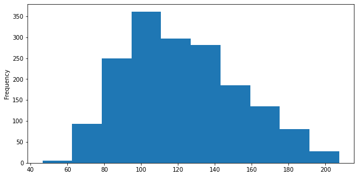

```python
data['tempo'].plot(kind='hist',bins = 10, figsize = (10,5))
```

### 문제 [2-5] - 7점

### 'Artist'가 BTS이면서 'Tempo'가 평균 이상인 것들을 다음과 같이 출력하세요.

#### (열(column)은 Rank, Track Name, Artist, tempo만 나오도록 하세요)

```python
mmm = data['tempo'].mean()
data[(data['tempo']>mmm) & (data['Artist'] == 'BTS' ) ][['Rank','Track Name','Artist','tempo']]
```

|  | Rank | Track Name | Artist | tempo |
| --- | --- | --- | --- | --- |
| 676 | 677.0 | Mikrokosmos | BTS | 174.039 |
| 678 | 679.0 | Dream Glow (BTS World Original Soundtrack) - P... | BTS | 141.948 |
| 710 | 711.0 | HOME | BTS | 142.991 |
| 725 | 726.0 | Dionysus | BTS | 176.084 |

# 문제 3 - 20점

### (아래 코드를 실행시켜 df1 변수에 저장 후, 시작해주세요)

```python
df1 =pd.DataFrame({'Class': ['IoT','Network', 'Economy','Big Data', 'Cloud'],
                       'Year': [2018, 2017, 2018, 2018, 2019],
                       'Price': [100, 125, 132, 312, 250],
                       'limitStudent': [40, 40, 40, 40, 40],
                       'Location': ['Korea','Korea', 'Korea', 'US','Korea']},
                      index=['C01','C02','C03', 'C04', 'C05'])
df1
```

|  | Class | Year | Price | limitStudent | Location |
| --- | --- | --- | --- | --- | --- |
| C01 | IoT | 2018 | 100 | 40 | Korea |
| C02 | Network | 2017 | 125 | 40 | Korea |
| C03 | Economy | 2018 | 132 | 40 | Korea |
| C04 | Big Data | 2018 | 312 | 40 | US |
| C05 | Cloud | 2019 | 250 | 40 | Korea |

### 문제 [3-1] - 2점

### C02, C03 강의의 Class, Year 열(column)을 출력하세요.

```python
df1[['Class','Year']].loc[['C02','C03']]
```

|  | Class | Year |
| --- | --- | --- |
| C02 | Network | 2017 |
| C03 | Economy | 2018 |

### 문제 [3-2] - 3점

### Year 열(column)에서 년도가 2018년도 혹은 2019년도에 개설된 Class 를 출력하세요.

```python
df1['Class'][(df1.Year == 2018)|(df1.Year == 2019)]
```

```
C01         IoT
C03     Economy
C04    Big Data
C05       Cloud
Name: Class, dtype: object
```

### 문제 [3-3] - 5점

### 강의 별 price 에 대한 세로형 막대 그래프를 출력하세요.

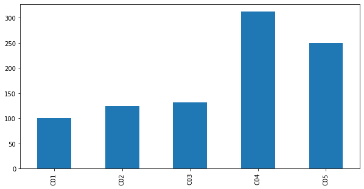

```python
df1['Price'].plot(kind = 'bar', figsize = (10,5))
```

### 문제 [3-4] - 10점

### priceLevel 열(column)을 추가하고 Price 열(column)의 값이 200보다 크거나 같으면 'High', 200 보다 작으면 'Low'를 할당하여 출력하세요.

### 이 때, get_priceLevel() 함수를 생성하여 priceLevel열의 값들을 추가하세요.

```python
def get_priceLevel(Price):
    if Price >=200:
        return 'High'
    else:
        return 'Low'

df1['priceLevel'] = df1['Price'].apply(get_priceLevel)
df1
```

|  | Class | Year | Price | limitStudent | Location | priceLevel |
| --- | --- | --- | --- | --- | --- | --- |
| C01 | IoT | 2018 | 100 | 40 | Korea | Low |
| C02 | Network | 2017 | 125 | 40 | Korea | Low |
| C03 | Economy | 2018 | 132 | 40 | Korea | Low |
| C04 | Big Data | 2018 | 312 | 40 | US | High |
| C05 | Cloud | 2019 | 250 | 40 | Korea | High |

# 문제4 - 20점

### 문제 [4-1] - 2점

### titanic.csv 를 titanic 변수에 저장하여 불러와주세요.

```python
titanic = pd.read_csv('titanic.csv')
titanic.head()
```

|  | PassengerId | Survived | Pclass | Name | Sex | Age | SibSp | Parch | Ticket | Fare | Cabin | Embarked |
| --- | --- | --- | --- | --- | --- | --- | --- | --- | --- | --- | --- | --- |
| 0 | 1 | 0 | 3 | Braund, Mr. Owen Harris | male | 22.0 | 1 | 0 | A/5 21171 | 7.2500 | NaN | S |
| 1 | 2 | 1 | 1 | Cumings, Mrs. John Bradley (Florence Briggs Th... | female | 38.0 | 1 | 0 | PC 17599 | 71.2833 | C85 | C |
| 2 | 3 | 1 | 3 | Heikkinen, Miss. Laina | female | 26.0 | 0 | 0 | STON/O2. 3101282 | 7.9250 | NaN | S |
| 3 | 4 | 1 | 1 | Futrelle, Mrs. Jacques Heath (Lily May Peel) | female | 35.0 | 1 | 0 | 113803 | 53.1000 | C123 | S |
| 4 | 5 | 0 | 3 | Allen, Mr. William Henry | male | 35.0 | 0 | 0 | 373450 | 8.0500 | NaN | S |

### 변수설명

- Survived : (0 : No, 1 : Yes) - 범주형
- pclass : Passenger Class (1=1st, 2=2nd, 3= 3rd) - 범주형
- Name
- Sex : 성별 -범주형
- Age : 나이
- SibSp : 동반한 배우자 / 형제 자매 수 - 수치형
- Parch : 부모 / 자식 수 - 수치형
- Ticket : 티켓번호 - 수치형
- fare : 승선 요금 - 수치형
- Cabin : 객실번호
- Embarked : 승선 항구 이름 (C = Chenbourg , Q = Queenstown, S = Southampton)

### 문제 [4-2] - 2점

### 결측값을 확인하세요.

```python
titanic.info()

titanic.isna().sum()
```

```
<class 'pandas.core.frame.DataFrame'>
RangeIndex: 891 entries, 0 to 890
Data columns (total 12 columns):
 #   Column       Non-Null Count  Dtype
---  ------       --------------  -----
 0   PassengerId  891 non-null    int64
 1   Survived     891 non-null    int64
 2   Pclass       891 non-null    int64
 3   Name         891 non-null    object
 4   Sex          891 non-null    object
 5   Age          714 non-null    float64
 6   SibSp        891 non-null    int64
 7   Parch        891 non-null    int64
 8   Ticket       891 non-null    object
 9   Fare         891 non-null    float64
 10  Cabin        204 non-null    object
 11  Embarked     889 non-null    object
dtypes: float64(2), int64(5), object(5)
memory usage: 83.7+ KB
```

```
PassengerId      0
Survived         0
Pclass           0
Name             0
Sex              0
Age            177
SibSp            0
Parch            0
Ticket           0
Fare             0
Cabin          687
Embarked         2
dtype: int64
```

### 문제 [4-3] - 4점

### 변수 Ticket, Cabin을 제거하세요.

```python
titanic.drop(['Cabin','Ticket'],axis=1,inplace=True)

titanic.info()
```

```
<class 'pandas.core.frame.DataFrame'>
RangeIndex: 891 entries, 0 to 890
Data columns (total 10 columns):
 #   Column       Non-Null Count  Dtype
---  ------       --------------  -----
 0   PassengerId  891 non-null    int64
 1   Survived     891 non-null    int64
 2   Pclass       891 non-null    int64
 3   Name         891 non-null    object
 4   Sex          891 non-null    object
 5   Age          714 non-null    float64
 6   SibSp        891 non-null    int64
 7   Parch        891 non-null    int64
 8   Fare         891 non-null    float64
 9   Embarked     889 non-null    object
dtypes: float64(2), int64(5), object(3)
memory usage: 69.7+ KB
```

### 문제 [4-4] - 6점

### age 변수의 결측값을 중간값으로 채워넣으세요.

```python
titanic['Age'].fillna(titanic['Age'].median(),inplace=True)
```

```python
titanic.info()
```

[output not shown]

### 문제 [4-5] - 6점

### 'Embarked' 변수의 결측값을 'S'로 채워넣으세요.

```python
titanic['Embarked'] = titanic['Embarked'].fillna('S')

titanic.info()
```

```
<class 'pandas.core.frame.DataFrame'>
RangeIndex: 891 entries, 0 to 890
Data columns (total 10 columns):
 #   Column       Non-Null Count  Dtype
---  ------       --------------  -----
 0   PassengerId  891 non-null    int64
 1   Survived     891 non-null    int64
 2   Pclass       891 non-null    int64
 3   Name         891 non-null    object
 4   Sex          891 non-null    object
 5   Age          891 non-null    float64
 6   SibSp        891 non-null    int64
 7   Parch        891 non-null    int64
 8   Fare         891 non-null    float64
 9   Embarked     891 non-null    object
dtypes: float64(2), int64(5), object(3)
memory usage: 69.7+ KB
```

# 문제 5 - 15점

### 문제 [5-1] - 3점

### 인구수예제.xlsx를 data_p로 불러온 후, 위에서부터 5행을 출력하세요.

```python
data_p = pd.read_excel('인구수예제.xlsx')
data_p.head()
```

|  | 도시 | 자치구 | 연도 | 남자인구 | 여자인구 | 총인구 |
| --- | --- | --- | --- | --- | --- | --- |
| 0 | 서울 | 강남구 | 2016 | 61 | 70 | 131 |
| 1 | 서울 | 강남구 | 2017 | 119 | 116 | 235 |
| 2 | 서울 | 강남구 | 2018 | 134 | 141 | 275 |
| 3 | 서울 | 강남구 | 2019 | 119 | 116 | 235 |
| 4 | 서울 | 강남구 | 2020 | 115 | 144 | 259 |

### 문제 [5-2] - 5점

### 연도별/도시별 총인구수를 구하세요.

```python
# 답1
data_p.groupby(['연도','도시'])['총인구'].sum()
```

```
연도    도시
2016  부산     832
      서울    1595
2017  부산     791
      서울    1517
2018  부산     790
      서울    1592
2019  부산     737
      서울    1456
2020  부산     896
      서울    1436
Name: 총인구, dtype: int64
```

```python
# 답2
data_p.pivot_table(index = '연도', columns = '도시', aggfunc = 'sum', values = '총인구')
```

| 도시 연도 | 부산 | 서울 |
| --- | --- | --- |
| 2016 | 832 | 1595 |
| 2017 | 791 | 1517 |
| 2018 | 790 | 1592 |
| 2019 | 737 | 1456 |
| 2020 | 896 | 1436 |

### 문제 [5-3] - 7점

### 도시/자치구별 평균 남자인구수와 여자인구수를 구하세요.

```python
data_p.groupby(['도시','자치구'])[['남자인구','여자인구']].mean()
```

| 도시 | 자치구 | 남자인구 | 여자인구 |
| --- | --- | --- | --- |
| 부산 | 동래구 | 91.4 | 122.8 |
|  | 수영구 | 90.2 | 98.4 |
|  | 중구 | 97.2 | 96.2 |
|  | 해운대구 | 107.2 | 105.8 |
| 서울 | 강남구 | 109.6 | 117.4 |
|  | 도봉구 | 101.8 | 74.4 |
|  | 동작구 | 87.4 | 63.2 |
|  | 서대문구 | 82.0 | 89.8 |
|  | 송파구 | 115.2 | 82.6 |
|  | 영등포구 | 112.8 | 115.6 |
|  | 종로구 | 75.8 | 113.2 |
|  | 중구 | 112.8 | 65.6 |